# Propensity Score Adjustment in ForestSearch: Complete Workflow

Implementation, Theory, and Simulation Evaluation

Author

Larry F. León

Published

March 25, 2026

```r
devtools::document(quiet = TRUE)
devtools::load_all(".", quiet = TRUE)
source("dev/glm/glm_effect_estimators.R")

suppressPackageStartupMessages({
  library(survival)
  library(data.table)
  library(grf)
  library(glmnet)
  library(gt)
  library(ggplot2)
})
theme_set(theme_minimal(base_size = 12))
```

# 1 Methodology

## 1.1 Doubly-Robust Estimation via the IPS Covariate

ForestSearch’s propensity score (PS) adjustment follows the doubly-robust methodology of Bang & Robins (2005). The key idea: include the **inverse propensity score** (IPS) as a covariate in the outcome model. This is distinct from inverse-probability-of-treatment weighting (IPTW).

For each subject $i$ with estimated propensity score $\hat{e}(X_i) = \hat{P}(W_i = 1 \mid X_i)$:

$$\text{IPS}_i = \begin{cases}
1 / \hat{e}(X_i) & \text{if } W_i = 1 \text{ (treated)} \\
1 / (1 - \hat{e}(X_i)) & \text{if } W_i = 0 \text{ (control)}
\end{cases}$$

The outcome model becomes:

$$g\bigl(E[Y_i \mid W_i, \text{IPS}_i]\bigr) = \beta_0 + \beta_1 W_i + \beta_2 \text{IPS}_i$$

## 1.2 Why IPS Covariate, Not IPTW

| Property | IPS Covariate | IPTW |
| --- | --- | --- |
| Model | `glm(Y ~ treat + ips_covar)` | `glm(Y ~ treat, weights = 1/e(x))` |
| Extreme PS | Absorbed by coefficient | Inflates variance |
| Small subgroups | Stable (just another covariate) | Unstable (extreme weights) |
| Doubly-robust | Yes (Bang & Robins 2005) | Only with augmentation (AIPW) |

For ForestSearch, the IPS covariate approach is preferred because the estimator closure is called repeatedly on **small subgroup slices** (down to `n.min = 60`). IPTW with extreme weights in small samples would be highly unstable.

# 2 Complete Workflow

## 2.1 Stage 1: GRF Screening (Internal PS)

When `use_grf = TRUE`, GRF fits `causal_forest(X, Y, W)` which internally estimates $\hat{e}(X_i) = E[W_i \mid X_i]$ via `regression_forest(X, W)`. These out-of-bag, cross-fitted propensity scores are used within GRF for:

- **Residualization**: $\tilde{W}_i = W_i - \hat{e}(X_i)$
- **Doubly-robust CATE scores**: The AIPW construction in `double_robust_scores()`
- **Variable importance**: Splits that explain treatment heterogeneity

The PS at this stage is used **only for candidate factor selection** — it does not affect the downstream effect estimates. For RCTs, `W.hat = 0.5` is passed (known randomization probability), so PS estimation is skipped.

```
causal_forest(X, Y, W, W.hat = 0.5)  # RCT
causal_forest(X, Y, W)                # Observational (W.hat estimated)
     ↓
double_robust_scores()  →  policy_tree()  →  candidate cuts
```

## 2.2 Stage 2: PS Estimation for Effect Adjustment

**Location:** `forestsearch_main.R`, Section 2C

After the outcome type and effect measure are resolved (Section 2B), ForestSearch optionally estimates propensity scores on the **full `df.analysis`** and constructs the IPS covariate.

```
forestsearch(..., ps_method = "grf", is.RCT = FALSE)
     ↓
  Section 2C: estimate_propensity_scores()
     ├── Estimate e(X) on full sample via GRF/LASSO/logistic
     ├── Trim PS to [2.5%, 97.5%]
     ├── Compute IPS covariate:
     │     W=1: 1/e(X)
     │     W=0: 1/(1-e(X))
     ├── Add ps_hat and ips_covar columns to df.analysis
     └── Rebuild estimator closure:
           make_effect_estimator(..., adjust_covariates = "ips_covar")
```

**Default behavior:**

| Setting | `ps_method` | IPS included | Rationale |
| --- | --- | --- | --- |
| `is.RCT = TRUE` | `"none"` | No | Randomization ensures balance |
| `is.RCT = FALSE` | `"grf"` | Yes | Non-parametric, cross-fitted |
| User-supplied | `ps_hat = vec` | Yes | Maximum flexibility |

## 2.3 Stage 3: Subgroup Search

**Location:** `subgroup_search.R` → `subgroup.consistency.R`

The estimator closure (now containing `adjust_covariates = "ips_covar"`) is called on **each candidate subgroup slice** during the search and consistency evaluation:

```
for each candidate subgroup S:
  df_slice <- df[df$candidate_var <= cutpoint, ]
     ↓
  estimator_fn(df_slice)
     → glm(Y ~ treat + ips_covar, data = df_slice, ...)
     → returns list(estimate, se, converged, ...)
```

**Critical detail:** The `ips_covar` values within each slice are the **full-sample** IPS values for those observations. The propensity scores are **never re-estimated** within subgroup slices. This is correct because:

1. $P(W = 1 \mid X)$ is a **design quantity** — it reflects the treatment assignment mechanism for the entire study, not a subgroup property.
2. Subgroup slices can be small ($n = 60$). Re-estimating a PS model with 7 covariates on 60 observations would be unstable.
3. Conditioning on the subgroup would violate the positivity assumption within slices and change the estimand.

## 2.4 Stage 4: Consistency Evaluation

**Location:** `subgroup.consistency.R`

For each candidate subgroup that passes the screening threshold, the consistency pipeline:

1. Splits the subgroup 50/50 randomly, `fs.splits` times
2. Applies the estimator closure to **each half-sample**
3. Checks whether both halves show treatment harm ($\hat\beta_1 \geq$ `hr.consistency`)

The IPS covariate flows through unchanged — each half-sample contains the original full-sample IPS values for its members.

## 2.5 Stage 5: Bootstrap Bias Correction

**Location:** `bootstrap_analysis_dofuture.R`

The bootstrap has **two distinct evaluations**, each with different PS handling:

### 2.5.1 Evaluation A: Original Subgroup on Bootstrap Data

```
df_boot <- df_boot_analysis[sample(N, N, replace = TRUE), ]
df_H <- subset(df_boot, treat.recommend == 0)
     ↓
estimator_fn(df_H)   # Uses ORIGINAL IPS values, resampled
```

The estimator closure (with `adjust_covariates = "ips_covar"`) is applied to the resampled data. The `ips_covar` column is carried from the original data — resampled subjects bring their original IPS values.

### 2.5.2 Evaluation B: Re-Selection (New Subgroup from Bootstrap Data)

```
args_FS_boot <- fs.est$args_call_all
args_FS_boot$df.analysis <- dfnew_boot   # bootstrap-resampled data
     ↓
do.call(forestsearch, args_FS_boot)
     ↓
  Section 2C re-entered:
    estimate_propensity_scores(dfnew_boot, ..., method = "grf")
    → FRESH PS estimated on bootstrap-resampled data
    → FRESH IPS covariate computed
    → FRESH estimator closure built
```

When `forestsearch()` is called on bootstrap data, it re-enters Section 2C and **re-estimates the propensity score** on the resampled data. This is methodologically correct: the bootstrap should replicate the entire estimation procedure, including PS estimation.

## 2.6 Stage 6: Summary Tables and Visualization

**Location:** `summary_utility_functions.R`

`SG_tab_estimates_glm()` and `format_bootstrap_table_gt()` use the estimator closure to compute subgroup-level effect estimates for display. The closure carries the `adjust_covariates` setting, so all displayed estimates are doubly-robust when PS adjustment is active.

# 3 PS Estimation Methods

## 3.1 GRF (`regression_forest`)

```r
df <- survival::gbsg
df$id <- seq_len(nrow(df))
df$grade3 <- as.integer(df$grade == "3")
confs <- c("age", "meno", "size", "grade3", "nodes", "pgr", "er")

# GRF PS estimation
ps_grf <- estimate_propensity_scores(df, "hormon", confs, method = "grf")

cat("GRF regression_forest PS:\n")
```

```
#> GRF regression_forest PS:
```

```r
cat("  N:", length(ps_grf$ps_hat), "\n")
```

```
#>   N: 686
```

```r
cat("  Mean PS:", round(mean(ps_grf$ps_hat), 4), "\n")
```

```
#>   Mean PS: 0.3588
```

```r
cat("  SD:", round(sd(ps_grf$ps_hat), 4), "\n")
```

```
#>   SD: 0.1174
```

```r
cat("  Range:", round(range(ps_grf$ps_hat), 4), "\n")
```

```
#>   Range: 0.1783 0.5733
```

```r
cat("  Trimmed:", ps_grf$trimmed, "\n")
```

```
#>   Trimmed: 0
```

```r
cat("  IPS covar range:", round(range(ps_grf$ips_covar), 2), "\n")
```

```
#>   IPS covar range: 1.22 5.61
```

**Properties:**

- Non-parametric: adapts to complex covariate-treatment relationships
- Cross-fitted via out-of-bag predictions (avoids overfitting)
- Already computed when `use_grf = TRUE` (zero additional cost)
- Default for observational studies

## 3.2 LASSO Logistic

```r
ps_lasso <- estimate_propensity_scores(df, "hormon", confs, method = "lasso")
cat("LASSO PS:\n")
```

```
#> LASSO PS:
```

```r
cat("  Cor with GRF:", round(cor(ps_grf$ps_hat, ps_lasso$ps_hat), 4), "\n")
```

```
#>   Cor with GRF: 0.955
```

```r
cat("  SD:", round(sd(ps_lasso$ps_hat), 4), "\n")
```

```
#>   SD: 0.1231
```

**Properties:**

- Penalized parametric model (logistic with L1 regularization)
- Automatic variable selection via `cv.glmnet`
- Well-suited when there are many covariates
- Fallback when `use_grf = FALSE`

## 3.3 Logistic Regression

```r
ps_logit <- estimate_propensity_scores(df, "hormon", confs, method = "logistic")
cat("Logistic PS:\n")
```

```
#> Logistic PS:
```

```r
cat("  Cor with GRF:", round(cor(ps_grf$ps_hat, ps_logit$ps_hat), 4), "\n")
```

```
#>   Cor with GRF: 0.9466
```

```r
cat("  SD:", round(sd(ps_logit$ps_hat), 4), "\n")
```

```
#>   SD: 0.1429
```

**Properties:**

- Simple, interpretable
- Standard in clinical trial practice
- May misspecify functional form (interactions, nonlinearities)

## 3.4 Comparison

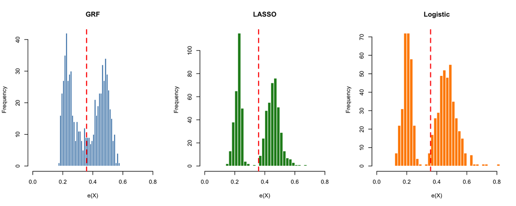

```r
par(mfrow = c(1, 3))
hist(ps_grf$ps_hat, breaks = 30, col = "steelblue", border = "white",
     main = "GRF", xlab = "e(X)", xlim = c(0, 0.8))
abline(v = mean(df$hormon), col = "red", lwd = 2, lty = 2)
hist(ps_lasso$ps_hat, breaks = 30, col = "forestgreen", border = "white",
     main = "LASSO", xlab = "e(X)", xlim = c(0, 0.8))
abline(v = mean(df$hormon), col = "red", lwd = 2, lty = 2)
hist(ps_logit$ps_hat, breaks = 30, col = "darkorange", border = "white",
     main = "Logistic", xlab = "e(X)", xlim = c(0, 0.8))
abline(v = mean(df$hormon), col = "red", lwd = 2, lty = 2)
```

```r
par(mfrow = c(1, 1))
```

# 4 Simulation Study

## 4.1 Data-Generating Mechanism

We simulate an observational study with confounded treatment assignment, a known subgroup with treatment harm, and a prognostic confounder that also drives treatment assignment.

```r
simulate_obs_study <- function(
    n = 2000, seed = 42L,
    confounding_strength = 1.0,    # controls strength of treatment-covariate association
    subgroup_effect = 0.8,         # log-OR for subgroup (harm)
    complement_effect = -0.4,      # log-OR for complement (benefit)
    prognostic_strength = 0.5,     # x3's effect on outcome
    n_noise = 3                    # number of noise covariates
) {
  set.seed(seed)

  # Covariates
  x1 <- rbinom(n, 1, 0.5)       # subgroup definer
  x2 <- rbinom(n, 1, 0.4)       # noise binary
  x3 <- rnorm(n)                 # confounder (affects both treatment AND outcome)
  x4 <- rnorm(n)                 # prognostic only
  noise <- matrix(rnorm(n * n_noise), n, n_noise)
  colnames(noise) <- paste0("noise", seq_len(n_noise))

  # Confounded treatment assignment
  # Treatment is more likely for patients with high x3 and x1 = 1
  lp_treat <- -0.5 + confounding_strength * (0.6 * x1 + 0.8 * x3 + 0.2 * x1 * x3)
  ps_true <- plogis(lp_treat)
  treat <- rbinom(n, 1, ps_true)

  # True subgroup: x1 == 1
  in_sg <- x1 == 1

  # Outcome model (binary event)
  # x3 is a prognostic confounder (affects outcome directly)
  lp_outcome <- -1.0 +
    prognostic_strength * x3 +     # confounding path
    0.3 * x4 +                     # prognostic only
    ifelse(in_sg, subgroup_effect, complement_effect) * treat

  event <- rbinom(n, 1, plogis(lp_outcome))

  # Follow-up time (for Poisson offset analyses)
  tte <- rexp(n, rate = 0.05) + 1

  df <- data.frame(
    id = seq_len(n), x1 = x1, x2 = x2, x3 = x3, x4 = x4,
    treat = treat, event = event, tte = tte,
    in_sg = in_sg, ps_true = ps_true
  )
  df <- cbind(df, noise)
  df
}
```

## 4.2 Scenario Definitions

```r
scenarios <- list(
  A = list(
    name = "Moderate confounding",
    confounding_strength = 0.8,
    subgroup_effect = 0.8,
    complement_effect = -0.4,
    prognostic_strength = 0.5,
    n_noise = 3
  ),
  B = list(
    name = "Strong confounding",
    confounding_strength = 1.5,
    subgroup_effect = 0.8,
    complement_effect = -0.4,
    prognostic_strength = 0.8,
    n_noise = 3
  ),
  C = list(
    name = "Very strong confounding + weak signal",
    confounding_strength = 2.0,
    subgroup_effect = 0.5,
    complement_effect = -0.2,
    prognostic_strength = 1.0,
    n_noise = 3
  ),
  D = list(
    name = "Strong confounding + many noise covariates",
    confounding_strength = 1.5,
    subgroup_effect = 0.8,
    complement_effect = -0.4,
    prognostic_strength = 0.8,
    n_noise = 10
  ),
  E = list(
    name = "No confounding (RCT benchmark)",
    confounding_strength = 0.0,
    subgroup_effect = 0.8,
    complement_effect = -0.4,
    prognostic_strength = 0.5,
    n_noise = 3
  )
)
```

## 4.3 Monte Carlo Evaluation

```r
n_sims <- 200
n_per_sim <- 2000

confs_sim <- c("x1", "x2", "x3", "x4")

run_mc <- function(scenario, n_sims, n_per_sim) {
  results <- data.frame(
    sim = integer(), method = character(),
    sg_est = numeric(), co_est = numeric(),
    stringsAsFactors = FALSE
  )

  # Expand confounders for noise variables
  all_confs <- c(confs_sim, paste0("noise", seq_len(scenario$n_noise)))

  for (s in seq_len(n_sims)) {
    df_s <- simulate_obs_study(
      n = n_per_sim, seed = s,
      confounding_strength  = scenario$confounding_strength,
      subgroup_effect       = scenario$subgroup_effect,
      complement_effect     = scenario$complement_effect,
      prognostic_strength   = scenario$prognostic_strength,
      n_noise               = scenario$n_noise
    )

    # GRF propensity scores
    ps_s <- estimate_propensity_scores(df_s, "treat", all_confs, method = "grf")
    df_s <- ps_s$data

    # Unadjusted estimator
    fn_u <- make_effect_estimator("binary", "treat", "event",
      effect_measure = "OR")

    # IPS-adjusted estimator (Bang & Robins)
    fn_a <- make_effect_estimator("binary", "treat", "event",
      effect_measure = "OR", adjust_covariates = "ips_covar")

    # Oracle-adjusted (true PS as covariate)
    df_s$ips_oracle <- ifelse(
      df_s$treat == 1, 1 / df_s$ps_true, 1 / (1 - df_s$ps_true))
    fn_o <- make_effect_estimator("binary", "treat", "event",
      effect_measure = "OR", adjust_covariates = "ips_oracle")

    sg <- df_s[df_s$x1 == 1, ]
    co <- df_s[df_s$x1 == 0, ]

    res_u_sg <- fn_u(sg); res_a_sg <- fn_a(sg); res_o_sg <- fn_o(sg)
    res_u_co <- fn_u(co); res_a_co <- fn_a(co); res_o_co <- fn_o(co)

    results <- rbind(results,
      data.frame(sim = s, method = "Unadjusted",
        sg_est = res_u_sg$estimate, co_est = res_u_co$estimate),
      data.frame(sim = s, method = "DR (GRF PS)",
        sg_est = res_a_sg$estimate, co_est = res_a_co$estimate),
      data.frame(sim = s, method = "DR (Oracle PS)",
        sg_est = res_o_sg$estimate, co_est = res_o_co$estimate)
    )
  }
  results
}

# Run all scenarios
all_results <- list()
for (sc_name in names(scenarios)) {
  cat("Running scenario", sc_name, ":", scenarios[[sc_name]]$name, "...\n")
  all_results[[sc_name]] <- run_mc(scenarios[[sc_name]], n_sims, n_per_sim)
}
```

```
#> Running scenario A : Moderate confounding ...
#> Running scenario B : Strong confounding ...
#> Running scenario C : Very strong confounding + weak signal ...
#> Running scenario D : Strong confounding + many noise covariates ...
#> Running scenario E : No confounding (RCT benchmark) ...
```

## 4.4 Results Summary

```r
summarize_scenario <- function(results, true_sg, true_co, scenario_name) {
  methods <- unique(results$method)
  rows <- list()

  for (m in methods) {
    sg <- results$sg_est[results$method == m]
    co <- results$co_est[results$method == m]

    rows[[length(rows) + 1]] <- data.frame(
      Scenario = scenario_name,
      Method = m,
      SG_Mean = round(mean(sg, na.rm = TRUE), 3),
      SG_Bias = round(mean(sg, na.rm = TRUE) - true_sg, 3),
      SG_RMSE = round(sqrt(mean((sg - true_sg)^2, na.rm = TRUE)), 3),
      CO_Mean = round(mean(co, na.rm = TRUE), 3),
      CO_Bias = round(mean(co, na.rm = TRUE) - true_co, 3),
      CO_RMSE = round(sqrt(mean((co - true_co)^2, na.rm = TRUE)), 3),
      stringsAsFactors = FALSE
    )
  }
  do.call(rbind, rows)
}

summary_table <- do.call(rbind, lapply(names(scenarios), function(sc) {
  sc_def <- scenarios[[sc]]
  summarize_scenario(
    all_results[[sc]],
    true_sg = sc_def$subgroup_effect,
    true_co = sc_def$complement_effect,
    scenario_name = paste0(sc, ": ", sc_def$name)
  )
}))

gt(summary_table) |>
  tab_header(
    title = md("**Monte Carlo Results: Unadjusted vs. Doubly-Robust**"),
    subtitle = sprintf("%d simulations, N = %d per simulation", n_sims, n_per_sim)
  ) |>
  tab_spanner(label = "Subgroup {x1=1}", columns = c(SG_Mean, SG_Bias, SG_RMSE)) |>
  tab_spanner(label = "Complement {x1=0}", columns = c(CO_Mean, CO_Bias, CO_RMSE)) |>
  cols_label(
    Scenario = "Scenario", Method = "Method",
    SG_Mean = "Mean", SG_Bias = "Bias", SG_RMSE = "RMSE",
    CO_Mean = "Mean", CO_Bias = "Bias", CO_RMSE = "RMSE"
  ) |>
  tab_source_note(
    md("True subgroup log-OR varies by scenario. DR = doubly-robust (IPS covariate, Bang & Robins 2005).")
  )
```

**Monte Carlo Results: Unadjusted vs. Doubly-Robust**

200 simulations, N = 2000 per simulation

| Scenario | Method | Subgroup {x1=1} Mean | Subgroup {x1=1} Bias | Subgroup {x1=1} RMSE | Complement {x1=0} Mean | Complement {x1=0} Bias | Complement {x1=0} RMSE |
| --- | --- | --- | --- | --- | --- | --- | --- |
| A: Moderate confounding | Unadjusted | 1.079 | 0.279 | 0.311 | -0.104 | 0.296 | 0.330 |
| A: Moderate confounding | DR (GRF PS) | 1.119 | 0.319 | 0.351 | -0.089 | 0.311 | 0.357 |
| A: Moderate confounding | DR (Oracle PS) | 1.083 | 0.283 | 0.315 | -0.035 | 0.365 | 0.405 |
| B: Strong confounding | Unadjusted | 1.485 | 0.685 | 0.701 | 0.302 | 0.702 | 0.716 |
| B: Strong confounding | DR (GRF PS) | 1.480 | 0.680 | 0.696 | 0.310 | 0.710 | 0.726 |
| B: Strong confounding | DR (Oracle PS) | 1.497 | 0.697 | 0.713 | 0.335 | 0.735 | 0.751 |
| C: Very strong confounding + weak signal | Unadjusted | 1.512 | 1.012 | 1.025 | 0.777 | 0.977 | 0.986 |
| C: Very strong confounding + weak signal | DR (GRF PS) | 1.511 | 1.011 | 1.023 | 0.786 | 0.986 | 0.996 |
| C: Very strong confounding + weak signal | DR (Oracle PS) | 1.529 | 1.029 | 1.042 | 0.802 | 1.002 | 1.012 |
| D: Strong confounding + many noise covariates | Unadjusted | 1.488 | 0.688 | 0.700 | 0.319 | 0.719 | 0.732 |
| D: Strong confounding + many noise covariates | DR (GRF PS) | 1.481 | 0.681 | 0.694 | 0.315 | 0.715 | 0.729 |
| D: Strong confounding + many noise covariates | DR (Oracle PS) | 1.496 | 0.696 | 0.708 | 0.351 | 0.751 | 0.766 |
| E: No confounding (RCT benchmark) | Unadjusted | 0.750 | -0.050 | 0.140 | -0.367 | 0.033 | 0.158 |
| E: No confounding (RCT benchmark) | DR (GRF PS) | 0.801 | 0.001 | 0.639 | -0.354 | 0.046 | 0.599 |
| E: No confounding (RCT benchmark) | DR (Oracle PS) | 0.750 | -0.050 | 0.140 | -0.367 | 0.033 | 0.158 |

True subgroup log-OR varies by scenario. DR = doubly-robust (IPS covariate, Bang & Robins 2005).

## 4.5 Boxplots by Scenario

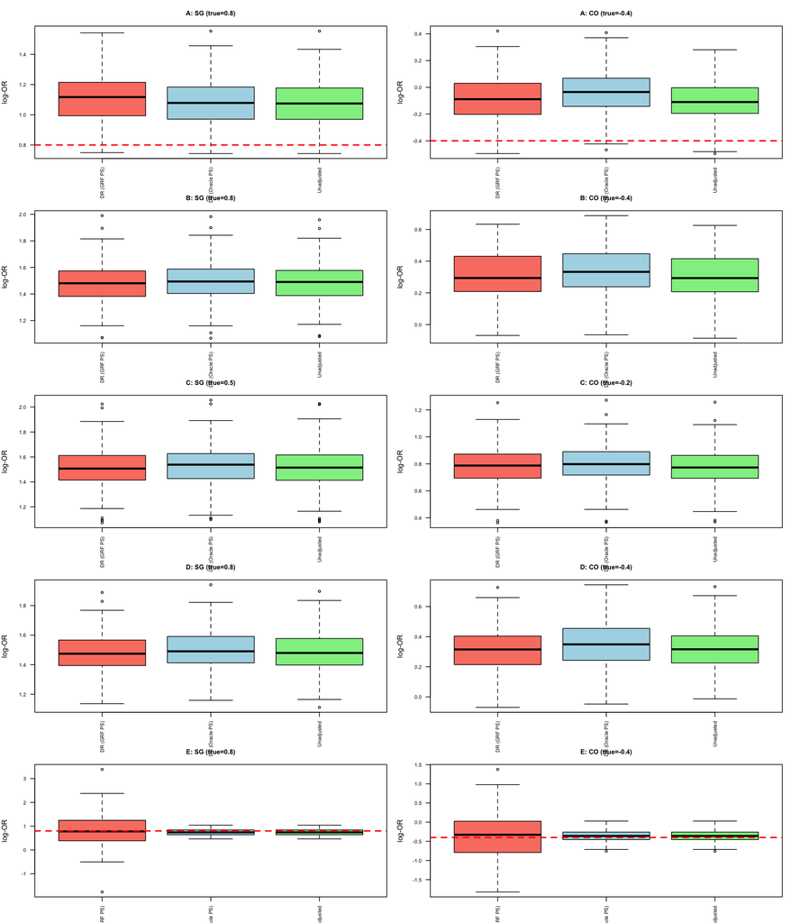

```r
par(mfrow = c(5, 2), mar = c(3, 4, 3, 1))

for (sc_name in names(scenarios)) {
  sc_def <- scenarios[[sc_name]]
  res <- all_results[[sc_name]]

  # Subgroup
  boxplot(sg_est ~ method, data = res,
    main = paste0(sc_name, ": SG (true=", sc_def$subgroup_effect, ")"),
    ylab = "log-OR", col = c("salmon", "lightblue", "lightgreen"),
    cex.main = 0.9, las = 2, cex.axis = 0.7)
  abline(h = sc_def$subgroup_effect, col = "red", lwd = 2, lty = 2)

  # Complement
  boxplot(co_est ~ method, data = res,
    main = paste0(sc_name, ": CO (true=", sc_def$complement_effect, ")"),
    ylab = "log-OR", col = c("salmon", "lightblue", "lightgreen"),
    cex.main = 0.9, las = 2, cex.axis = 0.7)
  abline(h = sc_def$complement_effect, col = "red", lwd = 2, lty = 2)
}
```

# 5 PS Quality Diagnostics

## 5.1 PS Calibration Across Confounding Strengths

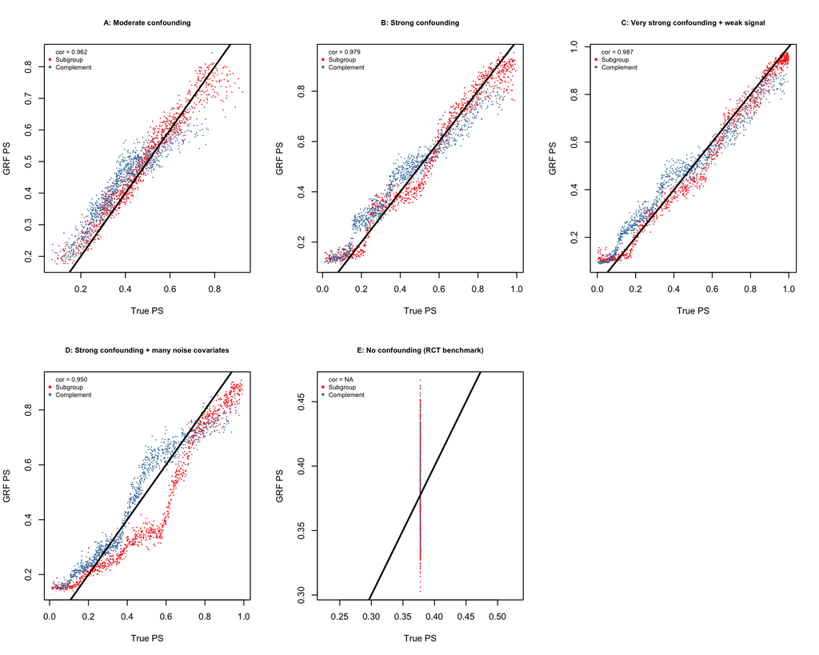

```r
par(mfrow = c(2, 3))

for (sc_name in c("A", "B", "C", "D", "E")) {
  sc_def <- scenarios[[sc_name]]
  df_s <- simulate_obs_study(
    n = 2000, seed = 42L,
    confounding_strength  = sc_def$confounding_strength,
    subgroup_effect       = sc_def$subgroup_effect,
    complement_effect     = sc_def$complement_effect,
    prognostic_strength   = sc_def$prognostic_strength,
    n_noise               = sc_def$n_noise
  )
  all_confs <- c(confs_sim, paste0("noise", seq_len(sc_def$n_noise)))
  ps_s <- estimate_propensity_scores(df_s, "treat", all_confs, method = "grf")

  plot(df_s$ps_true, ps_s$ps_hat, pch = 16, cex = 0.3,
       col = ifelse(df_s$in_sg, "red", "steelblue"),
       xlab = "True PS", ylab = "GRF PS",
       main = paste0(sc_name, ": ", sc_def$name),
       cex.main = 0.8)
  abline(0, 1, col = "black", lwd = 2)
  legend("topleft",
    legend = c(sprintf("cor = %.3f", cor(df_s$ps_true, ps_s$ps_hat)),
               "Subgroup", "Complement"),
    col = c(NA, "red", "steelblue"), pch = c(NA, 16, 16),
    cex = 0.7, bty = "n")
}

# Empty panel for layout
plot.new()
```

```r
par(mfrow = c(1, 1))
```

# 6 Positivity Diagnostics

## 6.1 IPS Covariate Distributions

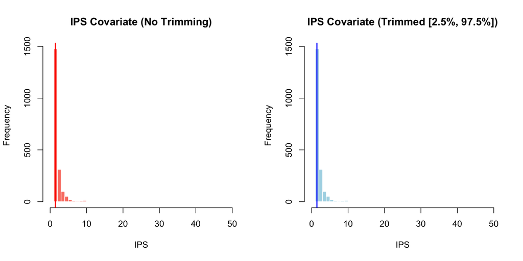

```r
# Strong confounding scenario
df_strong <- simulate_obs_study(
  n = 2000, seed = 42L,
  confounding_strength = 2.0, prognostic_strength = 1.0,
  n_noise = 3
)
all_confs_strong <- c(confs_sim, paste0("noise", 1:3))

ps_notrim <- estimate_propensity_scores(
  df_strong, "treat", all_confs_strong, method = "grf", trim = NULL)
ps_trim <- estimate_propensity_scores(
  df_strong, "treat", all_confs_strong, method = "grf")

par(mfrow = c(1, 2))
hist(ps_notrim$ips_covar, breaks = 50, col = "salmon", border = "white",
     main = "IPS Covariate (No Trimming)", xlab = "IPS", xlim = c(0, 50))
abline(v = median(ps_notrim$ips_covar), col = "red", lwd = 2)

hist(ps_trim$ips_covar, breaks = 50, col = "lightblue", border = "white",
     main = "IPS Covariate (Trimmed [2.5%, 97.5%])",
     xlab = "IPS", xlim = c(0, 50))
abline(v = median(ps_trim$ips_covar), col = "blue", lwd = 2)
```

```r
par(mfrow = c(1, 1))

cat("Without trimming: IPS range [",
    round(min(ps_notrim$ips_covar), 1), ",",
    round(max(ps_notrim$ips_covar), 1), "]\n")
```

```
#> Without trimming: IPS range [ 1 , 38.1 ]
```

```r
cat("With trimming:    IPS range [",
    round(min(ps_trim$ips_covar), 1), ",",
    round(max(ps_trim$ips_covar), 1), "]\n")
```

```
#> With trimming:    IPS range [ 1 , 38.1 ]
```

```r
cat("Trimmed observations:", ps_trim$trimmed, "\n")
```

```
#> Trimmed observations: 2
```

# 7 Key Principles

# 8 References

- Bang H, Robins JM (2005). “Doubly Robust Estimation in Missing Data and Causal Inference Models.” *Biometrics* 61(4): 962–973.
- León LF, Jemielita T, Guo Z, Marceau West R, Anderson KM (2024). “Exploratory subgroup identification in the heterogeneous Cox model.” *Statistics in Medicine*. DOI: 10.1002/sim.10163.
- Athey S, Tibshirani J, Wager S (2019). “Generalized Random Forests.” *Annals of Statistics* 47(2): 1148–1178.
- Robins JM, Rotnitzky A, Zhao LP (1994). “Estimation of Regression Coefficients When Some Regressors Are Not Always Observed.” *JASA* 89(427): 846–866.